# M.aurum

## Figures and Saving Files

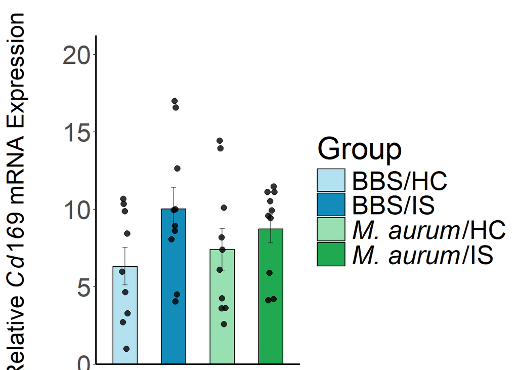

```r
### Relative gene expression ###
Cd169$Condition <- as.factor(Cd169$Condition)
Cd169$Treatment <- as.factor(Cd169$Treatment)
Cd169$Group <- factor(Cd169$Group, levels = c("BBS/HC", "BBS/IS", "M. aurum/HC", "M. aurum/IS"))


fig_Cd169 <- Cd169 %>%
  dplyr::group_by(Group) %>%
  dplyr::summarise(
    n = sum(!is.na(mRNA)),
    mean = mean(mRNA, na.rm = TRUE),
    sd = sd(mRNA, na.rm = TRUE),
    se = sd / sqrt(n),
    .groups = "drop"
  )

stoodis_colors <- c(
  "BBS/HC" = "#B3E1F0",
  "BBS/IS" = "#148CBA",
  "M. aurum/HC" = "#98E0B1",
  "M. aurum/IS" = "#21A951")

Cd169_plot <- ggplot(data = fig_Cd169, aes(x = Group, y = mean, fill = Group)) +
  geom_bar(stat = "identity", color = "black", width = 0.5) +
   scale_fill_manual(
    name = "Group",
    values = stoodis_colors,
    labels = c(
      "BBS/HC",
      "BBS/IS",
      expression(italic("M. aurum")*"/HC"),
      expression(italic("M. aurum")*"/IS")
    )
  ) +
  geom_jitter(
    data = Cd169,
    aes(x = Group, y = mRNA),
    width = 0.08,
    size = 2.5,
    alpha = 0.8,
    color = "black",
    inherit.aes = FALSE
  ) +
  theme(
    axis.text.x = element_blank(),
    axis.ticks.x = element_blank(),
    axis.title.x = element_blank()
  ) +
 scale_y_continuous(
  limits = c(0, NA),
  expand = expansion(mult = c(0, 0.25))
) +
  geom_errorbar(
    aes(ymin = mean - se, ymax = mean + se),
    width = 0.1,
    color = "black",
    alpha = 0.5,
    linewidth = 0.5
  ) +
   theme(
    panel.background = element_rect(fill = "white", colour = "white"),
    axis.text.x = element_blank(),
    axis.ticks.x = element_blank(),
    axis.title.x = element_blank(),
    axis.text.y = element_text(size = 25),
    axis.title.y = element_text(size = 23),
    axis.line = element_line(linewidth = 0.75, colour = "black", linetype = 1),
    plot.title = element_text(hjust = 0.5, size = 25, face = "italic"),
    legend.title = element_text(size = 30),
    legend.text = element_text(size = 25),
    legend.key.width = unit(1.0, "cm"),
    legend.key.height = unit(0.6, "cm")) +
  ggtitle("") +
  xlab("") +
  ylab(expression(atop(" Relative " * italic(Cd169) * " mRNA Expression")))
      #"(" * 2^{-Delta * Delta * C[q]} * " Values)")))
Cd169_plot
```

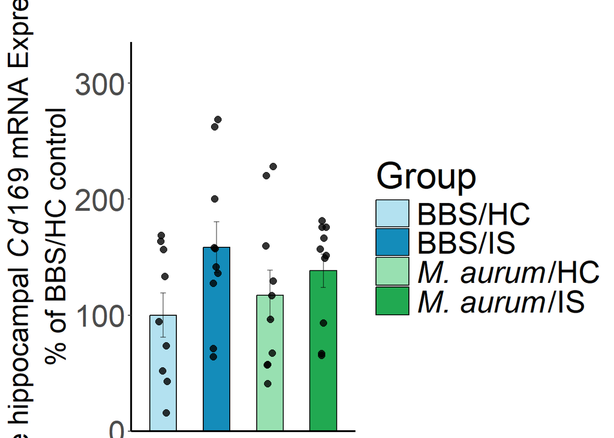

```r
### % to Control ###
Cd169_control$Condition <- as.factor(Cd169_control$Condition)
Cd169_control$Treatment <- as.factor(Cd169_control$Treatment)
Cd169_control$Group <- factor(Cd169_control$Group, levels = c("BBS/HC", "BBS/IS", "M. aurum/HC", "M. aurum/IS"))


fig_Cd169control <- Cd169_control %>%
  dplyr::group_by(Group) %>%
  dplyr::summarise(
    n = sum(!is.na(control)),
    mean = mean(control, na.rm = TRUE),
    sd = sd(control, na.rm = TRUE),
    se = sd / sqrt(n),
    .groups = "drop"
  )

stoodis_colors <- c(
  "BBS/HC" = "#B3E1F0",
  "BBS/IS" = "#148CBA",
  "M. aurum/HC" = "#98E0B1",
  "M. aurum/IS" = "#21A951")

Cd169control_plot <- ggplot(data = fig_Cd169control, aes(x = Group, y = mean, fill = Group)) +
  geom_bar(stat = "identity", color = "black", width = 0.5) +
  scale_fill_manual(
    name = "Group",
    values = stoodis_colors,
    labels = c(
      "BBS/HC",
      "BBS/IS",
      expression(italic("M. aurum")*"/HC"),
      expression(italic("M. aurum")*"/IS")
    )
  ) +
  geom_jitter(
    data = Cd169_control,
    aes(x = Group, y = control),
    width = 0.08,
    size = 2.5,
    alpha = 0.8,
    color = "black",
    inherit.aes = FALSE
  ) +
  theme(
    axis.text.x = element_blank(),
    axis.ticks.x = element_blank(),
    axis.title.x = element_blank()
  ) +
   scale_y_continuous(
  limits = c(0, NA),
  expand = expansion(mult = c(0, 0.25))
) +
  geom_errorbar(
    aes(ymin = mean - se, ymax = mean + se),
    width = 0.1,
    color = "black",
    alpha = 0.5,
    linewidth = 0.5
  ) +
  theme(
    panel.background = element_rect(fill = "white", colour = "white"),
    axis.text.x = element_blank(),
    axis.ticks.x = element_blank(),
    axis.title.x = element_blank(),
    axis.text.y = element_text(size = 25),
    axis.title.y = element_text(size = 23),
    axis.line = element_line(linewidth = 0.75, colour = "black", linetype = 1),
    plot.title = element_text(hjust = 0.5, size = 25, face = "italic"),
    legend.title = element_text(size = 30),
    legend.text = element_text(size = 25),
    legend.key.width = unit(1.0, "cm"),
    legend.key.height = unit(0.6, "cm")) +
  ggtitle("") +
  xlab("") +
   ylab(expression(atop(" Relative hippocampal " * italic(Cd169) * " mRNA Expression", "% of BBS/HC control")))
Cd169control_plot
```

```r
ggsave(
  filename = "Maurum_Data/R_figures/maurum_cd169_control.tiff",
  plot = Cd169control_plot,
  device = "tiff",
  units = "in",
  width = 20,
  height = 15,
  compression = "lzw"
)

ggsave(
  filename = "Maurum_Data/R_figures/maurum_cd169.tiff",
  plot = Cd169_plot,
  device = "tiff",
  units = "in",
  width = 20,
  height = 15,
  compression = "lzw"
)
```

# Linear Regression R. hippocampi Il6 vs. JSE Behavior (Condition and Treatment), R.hippocampi Cd169 vs. JSE Behavior (Condition and Treatment), Choroid Plexus Il6 vs. JSE Behavior

## Importing linear correlation data from Excel

```r
Il6_JSE_condition<- read_excel("Maurum_data/Regression/Il6_JSE_condition.xlsx")
Il6_JSE_treatment<- read_excel("Maurum_data/Regression/Il6_JSE_treatment.xlsx")
Cd169_JSE_condition<- read_excel("Maurum_data/Regression/Cd169_JSE_condition.xlsx")
Cd169_JSE_treatment<- read_excel("Maurum_data/Regression/Cd169_JSE_treatment.xlsx")
Il6_JSE_cp_condition <- read_excel("Maurum_data/Regression/Il6_JSE_cp_condition.xlsx")
Il6_JSE_cp_treatment <- read_excel("Maurum_data/Regression/Il6_JSE_cp_treatment.xlsx")
```

## Statistical Analysis: Grubbs and Shapiro’s

```r
grubbs.test(Il6_JSE_condition$mRNA[Il6_JSE_condition$group=="BBS/HC"], type = 10, opposite = F, two.sided = F)
```

```
##
##  Grubbs test for one outlier
##
## data:  Il6_JSE_condition$mRNA[Il6_JSE_condition$group == "BBS/HC"]
## G = 1.43931, U = 0.66178, p-value = 0.5219
## alternative hypothesis: lowest value 0.999609129 is an outlier
```

```r
grubbs.test(Il6_JSE_condition$mRNA[Il6_JSE_condition$group=="BBS/IS"], type = 10, opposite = F, two.sided = F)
```

```
##
##  Grubbs test for one outlier
##
## data:  Il6_JSE_condition$mRNA[Il6_JSE_condition$group == "BBS/IS"]
## G = 1.62417, U = 0.48707, p-value = 0.2458
## alternative hypothesis: lowest value 5.608179571 is an outlier
```

```r
grubbs.test(Il6_JSE_condition$JSE[Il6_JSE_condition$group=="BBS/HC"], type = 10, opposite = F, two.sided = F)
```

```
##
##  Grubbs test for one outlier
##
## data:  Il6_JSE_condition$JSE[Il6_JSE_condition$group == "BBS/HC"]
## G = 1.59501, U = 0.58464, p-value = 0.3381
## alternative hypothesis: lowest value 42.68156425 is an outlier
```

```r
grubbs.test(Il6_JSE_condition$JSE[Il6_JSE_condition$group=="BBS/IS"], type = 10, opposite = F, two.sided = F)
```

```
##
##  Grubbs test for one outlier
##
## data:  Il6_JSE_condition$JSE[Il6_JSE_condition$group == "BBS/IS"]
## G = 1.69047, U = 0.44434, p-value = 0.1906
## alternative hypothesis: lowest value 37.57429421 is an outlier
```

```r
grubbs.test(Il6_JSE_treatment$mRNA[Il6_JSE_treatment$group=="M. aurum/HC"],type = 10, opposite = F, two.sided = F)
```

```
##
##  Grubbs test for one outlier
##
## data:  Il6_JSE_treatment$mRNA[Il6_JSE_treatment$group == "M. aurum/HC"]
## G = 1.39883, U = 0.61952, p-value = 0.4903
## alternative hypothesis: highest value 10.26169001 is an outlier
```

```r
grubbs.test(Il6_JSE_treatment$mRNA[Il6_JSE_treatment$group=="M. aurum/IS"], type = 10, opposite = F, two.sided = F)
```

```
##
##  Grubbs test for one outlier
##
## data:  Il6_JSE_treatment$mRNA[Il6_JSE_treatment$group == "M. aurum/IS"]
## G = 1.87726, U = 0.42464, p-value = 0.1165
## alternative hypothesis: highest value 13.05209482 is an outlier
```

```r
grubbs.test(Il6_JSE_treatment$JSE[Il6_JSE_treatment$group=="M. aurum/HC"], type = 10, opposite = F, two.sided = F)
```

```
##
##  Grubbs test for one outlier
##
## data:  Il6_JSE_treatment$JSE[Il6_JSE_treatment$group == "M. aurum/HC"]
## G = 1.85727, U = 0.32927, p-value = 0.0848
## alternative hypothesis: highest value 117.2365755 is an outlier
```

```r
grubbs.test(Il6_JSE_treatment$JSE[Il6_JSE_treatment$group=="M. aurum/IS"], type = 10, opposite = F, two.sided = F)
```

```
##
##  Grubbs test for one outlier
##
## data:  Il6_JSE_treatment$JSE[Il6_JSE_treatment$group == "M. aurum/IS"]
## G = 1.68240, U = 0.53788, p-value = 0.2545
## alternative hypothesis: highest value 113.9100472 is an outlier
```

```r
shapiro.test(Il6_JSE_condition$mRNA[Il6_JSE_condition$group=="BBS/HC"])
```

```
##
##  Shapiro-Wilk normality test
##
## data:  Il6_JSE_condition$mRNA[Il6_JSE_condition$group == "BBS/HC"]
## W = 0.96322, p-value = 0.8402
```

```r
shapiro.test(Il6_JSE_condition$mRNA[Il6_JSE_condition$group=="BBS/IS"])
```

```
##
##  Shapiro-Wilk normality test
##
## data:  Il6_JSE_condition$mRNA[Il6_JSE_condition$group == "BBS/IS"]
## W = 0.97162, p-value = 0.9099
```

```r
shapiro.test(Il6_JSE_condition$JSE[Il6_JSE_condition$group=="BBS/HC"])
```

```
##
##  Shapiro-Wilk normality test
##
## data:  Il6_JSE_condition$JSE[Il6_JSE_condition$group == "BBS/HC"]
## W = 0.91108, p-value = 0.3617
```

```r
shapiro.test(Il6_JSE_condition$JSE[Il6_JSE_condition$group=="BBS/IS"])
```

```
##
##  Shapiro-Wilk normality test
##
## data:  Il6_JSE_condition$JSE[Il6_JSE_condition$group == "BBS/IS"]
## W = 0.97901, p-value = 0.9546
```

```r
shapiro.test(Il6_JSE_treatment$mRNA[Il6_JSE_treatment$group=="M. aurum/HC"])
```

```
##
##  Shapiro-Wilk normality test
##
## data:  Il6_JSE_treatment$mRNA[Il6_JSE_treatment$group == "M. aurum/HC"]
## W = 0.93491, p-value = 0.5934
```

```r
shapiro.test(Il6_JSE_treatment$mRNA[Il6_JSE_treatment$group=="M. aurum/IS"])
```

```
##
##  Shapiro-Wilk normality test
##
## data:  Il6_JSE_treatment$mRNA[Il6_JSE_treatment$group == "M. aurum/IS"]
## W = 0.78998, p-value = 0.02234
```

```r
# not normal p-value = 0.02234
shapiro.test(Il6_JSE_treatment$JSE[Il6_JSE_treatment$group=="M. aurum/HC"])
```

```
##
##  Shapiro-Wilk normality test
##
## data:  Il6_JSE_treatment$JSE[Il6_JSE_treatment$group == "M. aurum/HC"]
## W = 0.81196, p-value = 0.05368
```

```r
shapiro.test(Il6_JSE_treatment$JSE[Il6_JSE_treatment$group=="M. aurum/IS"])
```

```
##
##  Shapiro-Wilk normality test
##
## data:  Il6_JSE_treatment$JSE[Il6_JSE_treatment$group == "M. aurum/IS"]
## W = 0.97006, p-value = 0.8984
```

## Statistical Analysis: Pearson’s Correlation

```r
Il6_model <- lm(JSE ~ mRNA, data = Il6_JSE_condition)
summary(Il6_model)
```

```
##
## Call:
## lm(formula = JSE ~ mRNA, data = Il6_JSE_condition)
##
## Residuals:
##     Min      1Q  Median      3Q     Max
## -34.227 -16.848  -4.053  17.781  42.604
##
## Coefficients:
##             Estimate Std. Error t value Pr(>|t|)
## (Intercept)   88.593     15.343   5.774 6.44e-05 ***
## mRNA          -2.124      1.990  -1.067    0.305
## ---
## Signif. codes:  0 '***' 0.001 '**' 0.01 '*' 0.05 '.' 0.1 ' ' 1
##
## Residual standard error: 25.05 on 13 degrees of freedom
## Multiple R-squared:  0.08056,    Adjusted R-squared:  0.009839
## F-statistic: 1.139 on 1 and 13 DF,  p-value: 0.3053
```

```r
Il6_model2 <- lm(JSE ~ mRNA, data = Il6_JSE_treatment)
summary (Il6_model2)
```

```
##
## Call:
## lm(formula = JSE ~ mRNA, data = Il6_JSE_treatment)
##
## Residuals:
##     Min      1Q  Median      3Q     Max
## -36.602  -8.087  -0.862   7.948  31.022
##
## Coefficients:
##             Estimate Std. Error t value Pr(>|t|)
## (Intercept)   92.674     11.515   8.048 2.09e-06 ***
## mRNA          -1.372      1.576  -0.871      0.4
## ---
## Signif. codes:  0 '***' 0.001 '**' 0.01 '*' 0.05 '.' 0.1 ' ' 1
##
## Residual standard error: 18.69 on 13 degrees of freedom
## Multiple R-squared:  0.0551, Adjusted R-squared:  -0.01759
## F-statistic: 0.7581 on 1 and 13 DF,  p-value: 0.3997
```

```r
Cd169_model <- lm(JSE ~ mRNA, data = Cd169_JSE_condition)
summary (Cd169_model)
```

```
##
## Call:
## lm(formula = JSE ~ mRNA, data = Cd169_JSE_condition)
##
## Residuals:
##     Min      1Q  Median      3Q     Max
## -43.080 -21.197  -0.768  13.110  96.850
##
## Coefficients:
##             Estimate Std. Error t value Pr(>|t|)
## (Intercept)  131.406     17.710   7.420    1e-06 ***
## mRNA          -4.246      1.905  -2.229   0.0396 *
## ---
## Signif. codes:  0 '***' 0.001 '**' 0.01 '*' 0.05 '.' 0.1 ' ' 1
##
## Residual standard error: 35.23 on 17 degrees of freedom
## Multiple R-squared:  0.2261, Adjusted R-squared:  0.1806
## F-statistic: 4.967 on 1 and 17 DF,  p-value: 0.03962
```

```r
Cd169_model2 <- lm(JSE ~ mRNA, data = Cd169_JSE_treatment)
summary (Cd169_model2)
```

```
##
## Call:
## lm(formula = JSE ~ mRNA, data = Cd169_JSE_treatment)
##
## Residuals:
##     Min      1Q  Median      3Q     Max
## -39.914 -15.016   1.268  16.620  35.145
##
## Coefficients:
##             Estimate Std. Error t value Pr(>|t|)
## (Intercept)   52.507     12.658   4.148 0.000604 ***
## mRNA           3.198      1.438   2.224 0.039146 *
## ---
## Signif. codes:  0 '***' 0.001 '**' 0.01 '*' 0.05 '.' 0.1 ' ' 1
##
## Residual standard error: 22.57 on 18 degrees of freedom
## Multiple R-squared:  0.2156, Adjusted R-squared:  0.1721
## F-statistic: 4.948 on 1 and 18 DF,  p-value: 0.03915
```

```r
Il6_cp_model <- lm(JSE ~ mRNA, data = Il6_JSE_cp_condition)
summary(Il6_cp_model)
```

```
##
## Call:
## lm(formula = JSE ~ mRNA, data = Il6_JSE_cp_condition)
##
## Residuals:
##     Min      1Q  Median      3Q     Max
## -26.133 -12.785  -5.710   7.858  41.331
##
## Coefficients:
##             Estimate Std. Error t value Pr(>|t|)
## (Intercept)   79.037     13.549   5.834  0.00112 **
## mRNA          -2.029      1.369  -1.481  0.18899
## ---
## Signif. codes:  0 '***' 0.001 '**' 0.01 '*' 0.05 '.' 0.1 ' ' 1
##
## Residual standard error: 23.67 on 6 degrees of freedom
## Multiple R-squared:  0.2678, Adjusted R-squared:  0.1458
## F-statistic: 2.195 on 1 and 6 DF,  p-value: 0.189
```

```r
Il6_cp_model2 <- lm(JSE ~ mRNA, data = Il6_JSE_cp_treatment)
summary (Il6_cp_model2)
```

```
##
## Call:
## lm(formula = JSE ~ mRNA, data = Il6_JSE_cp_treatment)
##
## Residuals:
##     Min      1Q  Median      3Q     Max
## -26.739  -5.882  -1.985   6.626  30.324
##
## Coefficients:
##             Estimate Std. Error t value Pr(>|t|)
## (Intercept)  105.778     13.211   8.007 1.17e-05 ***
## mRNA          -3.655      2.349  -1.556    0.151
## ---
## Signif. codes:  0 '***' 0.001 '**' 0.01 '*' 0.05 '.' 0.1 ' ' 1
##
## Residual standard error: 16.4 on 10 degrees of freedom
## Multiple R-squared:  0.1949, Adjusted R-squared:  0.1144
## F-statistic: 2.421 on 1 and 10 DF,  p-value: 0.1508
```

## Figures and Saving Files- R. Hippocampi Il6 vs. JSE Condition and Treatment

```r
# R-squared for Il6 vs. JSE condition
r2_Il6c <- summary(Il6_model)$r.squared
# p-value for Il6 vs. JSE condition
pval_Il6c <- summary(Il6_model)$coefficients[2, 4]
# slope for Il6 vs. JSE condition
slope_Il6c <- summary(Il6_model)$coefficients[2, 1]

# R-squared for Il6 vs. JSE treatment
r2_Il6t <- summary(Il6_model2)$r.squared
# p-value for Il6 vs. JSE treatment
pval_Il6t <- summary(Il6_model2)$coefficients[2, 4]
# slope for Il6 vs. JSE treatment
slope_Il6t <- summary(Il6_model2)$coefficients[2, 1]

cat("Condition model:\n")
```

```
## Condition model:
```

```r
cat("R² =", round(r2_Il6c, 3), "\n")
```

```
## R² = 0.081
```

```r
cat("p-value =", signif(pval_Il6c, 3), "\n")
```

```
## p-value = 0.305
```

```r
cat("slope =", round(slope_Il6c, 3), "\n")
```

```
## slope = -2.124
```

```r
cat("Treatment model:\n")
```

```
## Treatment model:
```

```r
cat("R² =", round(r2_Il6t, 3), "\n")
```

```
## R² = 0.055
```

```r
cat("p-value =", signif(pval_Il6t, 3), "\n")
```

```
## p-value = 0.4
```

```r
cat("slope =", round(slope_Il6t, 3), "\n")
```

```
## slope = -1.372
```

```r
# Shared factor levels
all_groups <- c("BBS/HC", "BBS/IS", "M. aurum/HC", "M. aurum/IS")

# Colors
stoodis_colors <- c(
  "BBS/HC" = "#B3E1F0",
  "BBS/IS" = "#148CBA",
  "M. aurum/HC" = "#98E0B1",
  "M. aurum/IS" = "#21A951"
)

# Prepare condition data
Il6_JSE_condition <- Il6_JSE_condition %>%
  dplyr::mutate(
    Group = factor(group, levels = all_groups),
    mRNA = as.numeric(mRNA),
    JSE = as.numeric(JSE)
  )

# Prepare treatment data
Il6_JSE_treatment <- Il6_JSE_treatment %>%
  dplyr::mutate(
    Group = factor(group, levels = all_groups),
    mRNA = as.numeric(mRNA),
    JSE = as.numeric(JSE)
  )

# Panel A
Il6_JSE_condition_plot <- ggplot(Il6_JSE_condition, aes(x = mRNA, y = JSE, color = Group)) +
  geom_point(
    size = 6,
    alpha = 0.9
  ) +
   scale_color_manual(
    name = "Group",
    values = stoodis_colors,
    breaks = all_groups,
    labels = c(
      "BBS/HC",
      "BBS/IS",
      expression(italic("M. aurum") * "/HC"),
      expression(italic("M. aurum") * "/IS")
    ),
    drop = FALSE
  ) +
  geom_smooth(
    aes(group = 1),
    method = "lm",
    se = FALSE,
    color = "black",
    linewidth = 1,
    linetype = "solid"
  ) +
  stat_cor(
    aes(group = 1),
    method = "pearson",
    label.x = max(Il6_JSE_condition$mRNA, na.rm = TRUE),
    label.y = max(Il6_JSE_condition$JSE, na.rm = TRUE),
    size = 8,
    hjust = 1.2,
    color = "black",
    fontface = "bold"
  ) +
  theme_classic() +
  theme(
    axis.text = element_text(size = 25, color = "black"),
    axis.title = element_text(size = 28, color = "black"),
    axis.line = element_line(linewidth = 0.8),
    legend.position = "none",
    plot.title = element_text(size = 25, hjust = 0.5)
  ) +
     xlab(expression(atop("Relative hippocampal " * italic(Il6) * " mRNA Expression"))) +
  ylab(expression(atop("Time Exploring Juvenile", "% of BBS/HC control")))

# Panel B
Il6_JSE_treatment_plot <- ggplot(Il6_JSE_treatment, aes(x = mRNA, y = JSE, color = Group)) +
  geom_point(
    size = 6,
    alpha = 0.9
  ) +
  scale_color_manual(
    name = "Group",
    values = stoodis_colors,
    breaks = all_groups,
    labels = c(
      "BBS/HC",
      "BBS/IS",
      expression(italic("M. aurum") * "/HC"),
      expression(italic("M. aurum") * "/IS")
    ),
    drop = FALSE
  ) +
  geom_smooth(
    aes(group = 1),
    method = "lm",
    se = FALSE,
    color = "black",
    linewidth = 1,
    linetype = "solid"
  ) +
  stat_cor(
    aes(group = 1),
    method = "pearson",
    label.x = max(Il6_JSE_treatment$mRNA, na.rm = TRUE),
    label.y = max(Il6_JSE_treatment$JSE, na.rm = TRUE),
    size = 8,
    hjust = 1.2,
    color = "black",
    fontface = "bold"
  ) +
  theme_classic() +
  theme(
    axis.text = element_text(size = 25, color = "black"),
    axis.title = element_text(size = 28, color = "black"),
    axis.line = element_line(linewidth = 0.8),
    legend.position = "none",
    plot.title = element_text(size = 25, hjust = 0.5)
  ) +
     xlab(expression(atop("Relative hippocampal " * italic(Il6) * " mRNA Expression"))) +
  ylab(expression(atop("Time Exploring Juvenile", "% of BBS/HC control")))


# Arrange the two Il6 panels first
Il6_panel_plots <- ggarrange(
  Il6_JSE_condition_plot,
  Il6_JSE_treatment_plot,
  ncol = 2,
  nrow = 1,
  labels = c("A", "B"),
  widths = c(1, 1),
  font.label = list(size = 50, face = "bold")
)
# legend data
legend_Il6_df <- data.frame(
  x = 1:4,
  y = 1:4,
  Group = factor(all_groups, levels = all_groups)
)

# legend plot
legend_Il6_plot <- ggplot(legend_Il6_df, aes(x = x, y = y, color = Group)) +
  geom_point(size = 4) +
  scale_color_manual(
    name = "Group",
    values = stoodis_colors,
    breaks = all_groups,
    labels = c(
      "BBS/HC",
      "BBS/IS",
      expression(italic("M. aurum") * "/HC"),
      expression(italic("M. aurum") * "/IS")
    ),
    drop = FALSE
  ) +
  theme_classic() +
  theme(
    legend.title = element_text(size = 25),
    legend.text = element_text(size = 25),
    legend.position = "right"
  )

shared_Il6_legend <- cowplot::get_legend(legend_Il6_plot)

# Combine panels + legend
Il6_JSE_plots <- ggarrange(
  Il6_panel_plots,
  shared_Il6_legend,
  ncol = 2,
  widths = c(1, 0.22)
)

# Save TIFF
ggsave(
  filename = "Maurum_data/R_figures/maurum_Il6_JSE_plots.tiff",
  plot = Il6_JSE_plots,
  device = "tiff",
  width = 35,
  height = 15,
  units = "in",
  dpi = 600,
  compression = "lzw"
)
```

## Figures and Saving Files- R. Hipocampi Cd169 vs. JSE Condition and Treatment

```r
# R-squared for Cd169 vs. JSE condition
r2_Cd169c <- summary(Cd169_model)$r.squared
pval_Cd169c <- summary(Cd169_model)$coefficients[2, 4]
slope_Cd169c <- summary(Cd169_model)$coefficients[2, 1]

# R-squared for Cd169 vs. JSE treatment
r2_Cd169t <- summary(Cd169_model2)$r.squared
pval_Cd169t <- summary(Cd169_model2)$coefficients[2, 4]
slope_Cd169t <- summary(Cd169_model2)$coefficients[2, 1]

cat("Condition model:\n")
```

```
## Condition model:
```

```r
cat("R² =", round(r2_Cd169c, 3), "\n")
```

```
## R² = 0.226
```

```r
cat("p-value =", signif(pval_Cd169c, 3), "\n")
```

```
## p-value = 0.0396
```

```r
cat("slope =", round(slope_Cd169c, 3), "\n\n")
```

```
## slope = -4.246
```

```r
cat("Treatment model:\n")
```

```
## Treatment model:
```

```r
cat("R² =", round(r2_Cd169t, 3), "\n")
```

```
## R² = 0.216
```

```r
cat("p-value =", signif(pval_Cd169t, 3), "\n")
```

```
## p-value = 0.0391
```

```r
cat("slope =", round(slope_Cd169t, 3), "\n")
```

```
## slope = 3.198
```

[figure not shown]

```r
# Shared factor levels
all_groups <- c("BBS/HC", "BBS/IS", "M. aurum/HC", "M. aurum/IS")

# Colors
stoodis_colors <- c(
  "BBS/HC" = "#B3E1F0",
  "BBS/IS" = "#148CBA",
  "M. aurum/HC" = "#98E0B1",
  "M. aurum/IS" = "#21A951"
)

# Prepare condition data
Cd169_JSE_condition <- Cd169_JSE_condition %>%
  dplyr::mutate(
    Group = factor(group, levels = all_groups),
    mRNA = as.numeric(mRNA),
    JSE = as.numeric(JSE)
  )

# Prepare treatment data
Cd169_JSE_treatment <- Cd169_JSE_treatment %>%
  dplyr::mutate(
    Group = factor(group, levels = all_groups),
    mRNA = as.numeric(mRNA),
    JSE = as.numeric(JSE)
  )

# Panel A
Cd169_JSE_condition_plot <- ggplot(
  Cd169_JSE_condition,
  aes(x = mRNA, y = JSE, color = Group)
) +
  geom_point(
    size = 6,
    alpha = 0.9
  ) +
  scale_color_manual(
    name = "Group",
    values = stoodis_colors,
    breaks = all_groups,
    labels = c(
      "BBS/HC",
      "BBS/IS",
      expression(italic("M. aurum") * "/HC"),
      expression(italic("M. aurum") * "/IS")
    ),
    drop = FALSE
  ) +
  geom_smooth(
    aes(group = 1),
    method = "lm",
    se = FALSE,
    color = "black",
    linewidth = 1,
    linetype = "solid",
    alpha = 0.8
  ) +
  stat_cor(
    aes(group = 1),
    method = "pearson",
    label.x = Inf,
    label.y = Inf,
    hjust = 1.2,
    vjust = 1.5,
    size = 8,
    color = "black",
    fontface = "bold"
  ) +
  theme_classic() +
  theme(
    axis.text = element_text(size = 25, color = "black"),
    axis.title = element_text(size = 28, color = "black"),
    axis.line = element_line(linewidth = 0.8),
    legend.position = "none",
    plot.title = element_text(size = 25, hjust = 0.5)
  ) +
  xlab(expression(atop("Relative hippocampal " * italic(Cd169) * " mRNA Expression"))) +
  ylab(expression(atop("Time Exploring Juvenile", "% of BBS/HC control")))

# Panel B
Cd169_JSE_treatment_plot <- ggplot(
  Cd169_JSE_treatment,
  aes(x = mRNA, y = JSE, color = Group)
) +
  geom_point(
    size = 6,
    alpha = 0.9
  ) +
  scale_color_manual(
    name = "Group",
    values = stoodis_colors,
    breaks = all_groups,
    labels = c(
      "BBS/HC",
      "BBS/IS",
      expression(italic("M. aurum") * "/HC"),
      expression(italic("M. aurum") * "/IS")
    ),
    drop = FALSE
  ) +
  geom_smooth(
    aes(group = 1),
    method = "lm",
    se = FALSE,
    color = "black",
    linewidth = 1,
    linetype = "solid",
    alpha = 0.8
  ) +
  stat_cor(
    aes(group = 1),
    method = "pearson",
    label.x = Inf,
    label.y = Inf,
    hjust = 1.2,
    vjust = 1.5,
    size = 8,
    color = "black",
    fontface = "bold"
  ) +
  theme_classic() +
  theme(
    axis.text = element_text(size = 25, color = "black"),
    axis.title = element_text(size = 28, color = "black"),
    axis.line = element_line(linewidth = 0.8),
    legend.position = "none",
    plot.title = element_text(size = 25, hjust = 0.5)
  ) +
  xlab(expression(atop("Relative hippocampal " * italic(Cd169) * " mRNA Expression"))) +
  ylab(expression(atop("Time Exploring Juvenile", "% of BBS/HC control")))

# legend data
legend_df <- data.frame(
  x = 1:4,
  y = 1:4,
  Group = factor(all_groups, levels = all_groups)
)

# legend plot
legend_plot <- ggplot(legend_df, aes(x = x, y = y, color = Group)) +
  geom_point(size = 4) +
  scale_color_manual(
    name = "Group",
    values = stoodis_colors,
    breaks = all_groups,
    labels = c(
      "BBS/HC",
      "BBS/IS",
      expression(italic("M. aurum") * "/HC"),
      expression(italic("M. aurum") * "/IS")
    ),
    drop = FALSE
  ) +
  theme_classic() +
  theme(
    legend.title = element_text(size = 25),
    legend.text = element_text(size = 25),
    legend.position = "right",
    legend.key.height = unit(0.8, "cm"),
    legend.key.width = unit(1, "cm")
  )

shared_legend <- cowplot::get_legend(legend_plot)

# Arrange panels
panel_plots <- ggarrange(
  Cd169_JSE_condition_plot,
  Cd169_JSE_treatment_plot,
  ncol = 2,
  nrow = 1,
  labels = c("A", "B"),
  widths = c(1, 1),
  font.label = list(size = 50, face = "bold")
)
# Combine panels + legend
Cd169_JSE_plots <- ggarrange(
  panel_plots,
  shared_legend,
  ncol = 2,
  widths = c(1, 0.22)
)

Cd169_JSE_plots
```

```r
# Save TIFF
ggsave(
  filename = "Maurum_data/R_figures/maurum_Cd169_JSE_plots.tiff",
  plot = Cd169_JSE_plots,
  device = "tiff",
  width = 35,
  height = 15,
  dpi = 600,
  units = "in",
  compression = "lzw"
)
```

## Figures and Saving Files- CP Il6 vs. JSE Condition and Treatment

```r
# R-squared for Il6 vs. JSE condition for linear regression model
r2_Il6c_cp <- summary(Il6_cp_model)$r.squared
# p-value for Cd169 vs. JSE condition for linear regressions model
pval_Il6c_cp <- summary(Il6_cp_model)$coefficients[2, 4]
# slope for Cd169 vs. JSE condition
slope_Il6c_cp <- summary(Il6_cp_model)$coefficients[2, 1]

# R-squared for Il6 vs. JSE treatment
r2_Il6t_cp <- summary(Il6_cp_model2)$r.squared
# p-value for Cd169 vs. JSE treatment
pval_Il6t_cp <- summary(Il6_cp_model2)$coefficients[2, 4]
# slope for Cd169 vs. JSE treatment
slope_Il6t_cp <- summary(Il6_cp_model2)$coefficients[2, 1]


cat("Condition model:\n")
```

```
## Condition model:
```

```r
cat("R² =", round(r2_Il6c_cp, 3), "\n")
```

```
## R² = 0.268
```

```r
cat("p-value =", signif(pval_Il6c_cp, 3), "\n")
```

```
## p-value = 0.189
```

```r
cat("slope =", round(slope_Il6c_cp, 3), "\n")
```

```
## slope = -2.029
```

```r
cat("Treatment model:\n")
```

```
## Treatment model:
```

```r
cat("R² =", round(r2_Il6t_cp, 3), "\n")
```

```
## R² = 0.195
```

```r
cat("p-value =", signif(pval_Il6t_cp, 3), "\n")
```

```
## p-value = 0.151
```

```r
cat("slope =", round(slope_Il6t_cp, 3), "\n")
```

```
## slope = -3.655
```

```r
# Shared factor levels
all_groups <- c("BBS/HC", "BBS/IS", "M. aurum/HC", "M. aurum/IS")

# Colors
stoodis_colors <- c(
  "BBS/HC" = "#B3E1F0",
  "BBS/IS" = "#148CBA",
  "M. aurum/HC" = "#98E0B1",
  "M. aurum/IS" = "#21A951"
)

# Prepare condition data
Il6_JSE_cp_condition <- Il6_JSE_cp_condition %>%
  dplyr::mutate(
    Group = factor(group, levels = all_groups),
    mRNA = as.numeric(mRNA),
    JSE = as.numeric(JSE)
  )

# Prepare treatment data
Il6_JSE_cp_treatment <- Il6_JSE_cp_treatment %>%
  dplyr::mutate(
    Group = factor(group, levels = all_groups),
    mRNA = as.numeric(mRNA),
    JSE = as.numeric(JSE)
  )

# Panel A
Il6_JSE_cp_condition_plot <- ggplot(Il6_JSE_cp_condition, aes(x = mRNA, y = JSE, color = Group)) +
  geom_point(
    size = 6,
    alpha = 0.9
  ) +
   scale_color_manual(
    name = "Group",
    values = stoodis_colors,
    breaks = all_groups,
    labels = c(
      "BBS/HC",
      "BBS/IS",
      expression(italic("M. aurum") * "/HC"),
      expression(italic("M. aurum") * "/IS")
    ),
    drop = FALSE
  ) +
  geom_smooth(
    aes(group = 1),
    method = "lm",
    se = FALSE,
    color = "black",
    linewidth = 1,
    linetype = "solid"
  ) +
  stat_cor(
    aes(group = 1),
    method = "pearson",
    label.x = max(Il6_JSE_cp_condition$mRNA, na.rm = TRUE),
    label.y = max(Il6_JSE_cp_condition$JSE, na.rm = TRUE),
    size = 8,
    hjust = 1.2,
    color = "black",
    fontface = "bold"
  ) +
  theme_classic() +
  theme(
    axis.text = element_text(size = 25, color = "black"),
    axis.title = element_text(size = 28, color = "black"),
    axis.line = element_line(linewidth = 0.8),
    legend.position = "none",
    plot.title = element_text(size = 25, hjust = 0.5)
  ) +
     xlab(expression(atop("Relative choroid plexus " * italic(Il6) * " mRNA Expression"))) +
  ylab(expression(atop("Time Exploring Juvenile", "% of BBS/HC control")))

# Panel B
Il6_JSE_cp_treatment_plot <- ggplot(Il6_JSE_cp_treatment, aes(x = mRNA, y = JSE, color = Group)) +
  geom_point(
    size = 6,
    alpha = 0.9
  ) +
  scale_color_manual(
    name = "Group",
    values = stoodis_colors,
    breaks = all_groups,
    labels = c(
      "BBS/HC",
      "BBS/IS",
      expression(italic("M. aurum") * "/HC"),
      expression(italic("M. aurum") * "/IS")
    ),
    drop = FALSE
  ) +
  geom_smooth(
    aes(group = 1),
    method = "lm",
    se = FALSE,
    color = "black",
    linewidth = 1,
    linetype = "solid"
  ) +
  stat_cor(
    aes(group = 1),
    method = "pearson",
    label.x = max(Il6_JSE_cp_treatment$mRNA, na.rm = TRUE),
    label.y = max(Il6_JSE_cp_treatment$JSE, na.rm = TRUE),
    size = 8,
    hjust = 1.2,
    color = "black"
  ) +
  theme_classic() +
  theme(
    axis.text = element_text(size = 25, color = "black"),
    axis.title = element_text(size = 28, color = "black"),
    axis.line = element_line(linewidth = 0.8),
    legend.position = "none",
    plot.title = element_text(size = 25, hjust = 0.5)
  ) +
     xlab(expression(atop("Relative choroid plexus " * italic(Il6) * " mRNA Expression"))) +
  ylab(expression(atop("Time Exploring Juvenile", "% of BBS/HC control")))


# Arrange the two Il6 panels first
Il6_cp_panel_plots <- ggarrange(
  Il6_JSE_cp_condition_plot,
  Il6_JSE_cp_treatment_plot,
  ncol = 2,
  nrow = 1,
  labels = c("A", "B"),
  widths = c(1, 1),
  font.label = list(size = 50, face = "bold")
)
# legend data
legend_Il6_cp_df <- data.frame(
  x = 1:4,
  y = 1:4,
  Group = factor(all_groups, levels = all_groups)
)

# legend plot
legend_Il6_cp_plot <- ggplot(legend_Il6_cp_df, aes(x = x, y = y, color = Group)) +
  geom_point(size = 4) +
  scale_color_manual(
    name = "Group",
    values = stoodis_colors,
    breaks = all_groups,
    labels = c(
      "BBS/HC",
      "BBS/IS",
      expression(italic("M. aurum") * "/HC"),
      expression(italic("M. aurum") * "/IS")
    ),
    drop = FALSE
  ) +
  theme_classic() +
  theme(
    legend.title = element_text(size = 25),
    legend.text = element_text(size = 25),
    legend.position = "right"
  )

shared_Il6_cp_legend <- cowplot::get_legend(legend_Il6_cp_plot)

# Combine panels + legend
Il6_JSE_cp_plots <- ggarrange(
  Il6_cp_panel_plots,
  shared_Il6_cp_legend,
  ncol = 2,
  widths = c(1, 0.22)
)

# Save TIFF
ggsave(
  filename = "Maurum_data/R_figures/maurum_Il6_JSE_cp_plots.tiff",
  plot = Il6_JSE_cp_plots,
  device = "tiff",
  width = 35,
  height = 15,
  units = "in",
  dpi = 600,
  compression = "lzw"
)
```